# Risk Factor Analysis

## Outcome Variable

**Outcome Variable:** haz

## Predictor Variables

**Intervention Variable:** hfoodsec

**Adjustment Set:**

- arm
- sex
- W_mage
- meducyrs
- feducyrs
- hhwealth_quart
- vagbrth
- W_nrooms
- W_nchldlt5
- brthmon
- W_parity
- impfloor
- impsan
- safeh20
- delta_W_mage
- delta_meducyrs
- delta_feducyrs
- delta_hhwealth_quart
- delta_vagbrth
- delta_W_nrooms
- delta_W_nchldlt5
- delta_brthmon
- delta_W_parity
- delta_impfloor
- delta_impsan
- delta_safeh20

## Stratifying Variables

The analysis was stratified on these variable(s):

- agecat
- studyid
- country

## Data Summary

| agecat | studyid | country | hfoodsec | n_cell | n |
| --- | --- | --- | --- | --- | --- |
| Birth | ki0047075b-MAL-ED | BANGLADESH | Food Secure | 144 | 172 |
| Birth | ki0047075b-MAL-ED | BANGLADESH | Mildly Food Insecure | 4 | 172 |
| Birth | ki0047075b-MAL-ED | BANGLADESH | Food Insecure | 24 | 172 |
| Birth | ki0047075b-MAL-ED | BRAZIL | Food Secure | 0 | 28 |
| Birth | ki0047075b-MAL-ED | BRAZIL | Mildly Food Insecure | 4 | 28 |
| Birth | ki0047075b-MAL-ED | BRAZIL | Food Insecure | 24 | 28 |
| Birth | ki0047075b-MAL-ED | INDIA | Food Secure | 34 | 37 |
| Birth | ki0047075b-MAL-ED | INDIA | Mildly Food Insecure | 1 | 37 |
| Birth | ki0047075b-MAL-ED | INDIA | Food Insecure | 2 | 37 |
| Birth | ki0047075b-MAL-ED | NEPAL | Food Secure | 10 | 14 |
| Birth | ki0047075b-MAL-ED | NEPAL | Mildly Food Insecure | 1 | 14 |
| Birth | ki0047075b-MAL-ED | NEPAL | Food Insecure | 3 | 14 |
| Birth | ki0047075b-MAL-ED | PERU | Food Secure | 24 | 91 |
| Birth | ki0047075b-MAL-ED | PERU | Mildly Food Insecure | 23 | 91 |
| Birth | ki0047075b-MAL-ED | PERU | Food Insecure | 44 | 91 |
| Birth | ki0047075b-MAL-ED | SOUTH AFRICA | Food Secure | 45 | 88 |
| Birth | ki0047075b-MAL-ED | SOUTH AFRICA | Mildly Food Insecure | 9 | 88 |
| Birth | ki0047075b-MAL-ED | SOUTH AFRICA | Food Insecure | 34 | 88 |
| Birth | ki1017093-NIH-Birth | BANGLADESH | Food Secure | 90 | 608 |
| Birth | ki1017093-NIH-Birth | BANGLADESH | Mildly Food Insecure | 478 | 608 |
| Birth | ki1017093-NIH-Birth | BANGLADESH | Food Insecure | 40 | 608 |
| Birth | ki1017093c-NIH-Crypto | BANGLADESH | Food Secure | 439 | 732 |
| Birth | ki1017093c-NIH-Crypto | BANGLADESH | Mildly Food Insecure | 209 | 732 |
| Birth | ki1017093c-NIH-Crypto | BANGLADESH | Food Insecure | 84 | 732 |
| Birth | ki1113344-GMS-Nepal | NEPAL | Food Secure | 477 | 672 |
| Birth | ki1113344-GMS-Nepal | NEPAL | Mildly Food Insecure | 106 | 672 |
| Birth | ki1113344-GMS-Nepal | NEPAL | Food Insecure | 89 | 672 |
| Birth | kiGH5241-JiVitA-3 | BANGLADESH | Food Secure | 8512 | 16994 |
| Birth | kiGH5241-JiVitA-3 | BANGLADESH | Mildly Food Insecure | 5660 | 16994 |
| Birth | kiGH5241-JiVitA-3 | BANGLADESH | Food Insecure | 2822 | 16994 |

[output cut: 69 more lines]

The following strata were considered:

- agecat: 24 months, studyid: ki0047075b-MAL-ED, country: BANGLADESH
- agecat: 24 months, studyid: ki0047075b-MAL-ED, country: BRAZIL
- agecat: 24 months, studyid: ki0047075b-MAL-ED, country: INDIA
- agecat: 24 months, studyid: ki0047075b-MAL-ED, country: NEPAL
- agecat: 24 months, studyid: ki0047075b-MAL-ED, country: PERU
- agecat: 24 months, studyid: ki0047075b-MAL-ED, country: SOUTH AFRICA
- agecat: 24 months, studyid: ki1017093-NIH-Birth, country: BANGLADESH
- agecat: 24 months, studyid: ki1017093c-NIH-Crypto, country: BANGLADESH
- agecat: 24 months, studyid: ki1113344-GMS-Nepal, country: NEPAL
- agecat: 24 months, studyid: kiGH5241-JiVitA-3, country: BANGLADESH
- agecat: 24 months, studyid: kiGH5241-JiVitA-4, country: BANGLADESH
- agecat: 6 months, studyid: ki0047075b-MAL-ED, country: BANGLADESH
- agecat: 6 months, studyid: ki0047075b-MAL-ED, country: BRAZIL
- agecat: 6 months, studyid: ki0047075b-MAL-ED, country: INDIA
- agecat: 6 months, studyid: ki0047075b-MAL-ED, country: NEPAL
- agecat: 6 months, studyid: ki0047075b-MAL-ED, country: PERU
- agecat: 6 months, studyid: ki0047075b-MAL-ED, country: SOUTH AFRICA
- agecat: 6 months, studyid: ki1017093-NIH-Birth, country: BANGLADESH
- agecat: 6 months, studyid: ki1017093c-NIH-Crypto, country: BANGLADESH
- agecat: 6 months, studyid: ki1113344-GMS-Nepal, country: NEPAL
- agecat: 6 months, studyid: kiGH5241-JiVitA-3, country: BANGLADESH
- agecat: 6 months, studyid: kiGH5241-JiVitA-4, country: BANGLADESH
- agecat: Birth, studyid: ki0047075b-MAL-ED, country: BANGLADESH
- agecat: Birth, studyid: ki0047075b-MAL-ED, country: BRAZIL
- agecat: Birth, studyid: ki0047075b-MAL-ED, country: INDIA
- agecat: Birth, studyid: ki0047075b-MAL-ED, country: NEPAL
- agecat: Birth, studyid: ki0047075b-MAL-ED, country: PERU
- agecat: Birth, studyid: ki0047075b-MAL-ED, country: SOUTH AFRICA
- agecat: Birth, studyid: ki1017093-NIH-Birth, country: BANGLADESH
- agecat: Birth, studyid: ki1017093c-NIH-Crypto, country: BANGLADESH
- agecat: Birth, studyid: ki1113344-GMS-Nepal, country: NEPAL
- agecat: Birth, studyid: kiGH5241-JiVitA-3, country: BANGLADESH
- agecat: Birth, studyid: kiGH5241-JiVitA-4, country: BANGLADESH

### Dropped Strata

Some strata were dropped due to rare outcomes:

- agecat: Birth, studyid: ki0047075b-MAL-ED, country: BANGLADESH
- agecat: Birth, studyid: ki0047075b-MAL-ED, country: BRAZIL
- agecat: Birth, studyid: ki0047075b-MAL-ED, country: INDIA
- agecat: Birth, studyid: ki0047075b-MAL-ED, country: NEPAL
- agecat: 6 months, studyid: ki0047075b-MAL-ED, country: BANGLADESH
- agecat: 6 months, studyid: ki0047075b-MAL-ED, country: BRAZIL
- agecat: 24 months, studyid: ki0047075b-MAL-ED, country: BANGLADESH
- agecat: 24 months, studyid: ki0047075b-MAL-ED, country: BRAZIL

## Methods Detail

We’re interested in the causal parameters $E[Y_a]$ for all values of $a \in \mathcal{A}$. These parameters represent the mean outcome if, possibly contrary to fact, we intervened to set all units to have $A=a$. Under the randomization and positivity assumptions, these are identified by the statistical parameters $\psi_a=E_W[E_{Y|A,W}(Y|A=a,W)]$. In addition, we’re interested in the mean of $Y$, $E[Y]$ under no intervention (the observed mean). We will estimate these parameters by using SuperLearner to fit the relevant likelihood factors – $E_{Y|A,W}(Y|A=a,W)$ and $p(A=a|W)$, and then updating our likelihood fit using a joint TMLE.

For unadjusted analyses ($W=\{\}$), initial likelihoods were estimated using Lrnr_glm to estimate the simple $E(Y|A)$ and Lrnr_mean to estimate $p(A)$. For adjusted analyses, a small library containing Lrnr_glmnet, Lrnr_xgboost, and Lrnr_mean was used.

Having estimated these parameters, we will then use the delta method to estimate relative risks and attributable risks relative to a prespecified baseline level of $A$.

# Results Detail

## Results Plots

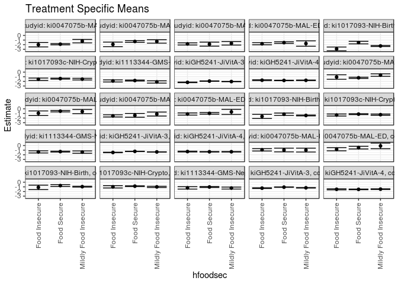

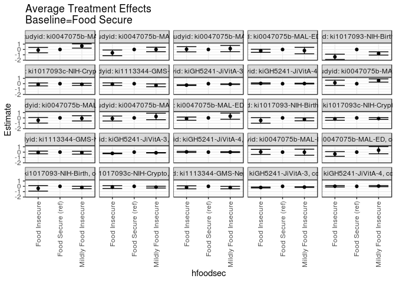

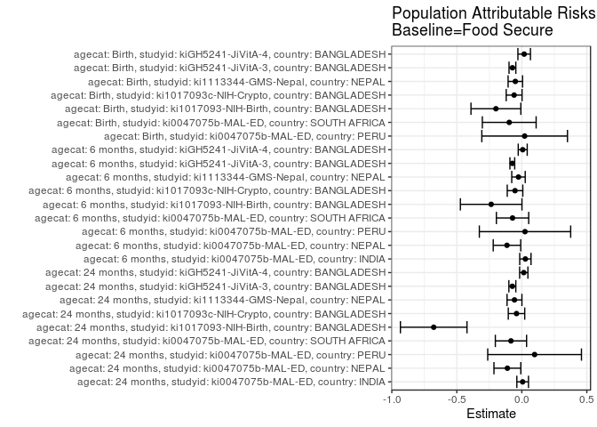

## Results Table

### Parameter: TSM

| agecat | studyid | country | intervention_level | baseline_level | estimate | ci_lower | ci_upper |
| --- | --- | --- | --- | --- | --- | --- | --- |
| Birth | ki0047075b-MAL-ED | PERU | Food Secure | NA | -0.9707956 | -1.3667235 | -0.5748677 |
| Birth | ki0047075b-MAL-ED | PERU | Mildly Food Insecure | NA | -0.9851429 | -1.3995931 | -0.5706927 |
| Birth | ki0047075b-MAL-ED | PERU | Food Insecure | NA | -0.9292255 | -1.1855051 | -0.6729459 |
| Birth | ki0047075b-MAL-ED | SOUTH AFRICA | Food Secure | NA | -0.4535556 | -0.7370575 | -0.1700536 |
| Birth | ki0047075b-MAL-ED | SOUTH AFRICA | Mildly Food Insecure | NA | -0.0888889 | -0.6955550 | 0.5177773 |
| Birth | ki0047075b-MAL-ED | SOUTH AFRICA | Food Insecure | NA | -0.8005882 | -1.1433809 | -0.4577955 |
| Birth | ki1017093-NIH-Birth | BANGLADESH | Food Secure | NA | -0.7317773 | -0.9346106 | -0.5289440 |
| Birth | ki1017093-NIH-Birth | BANGLADESH | Mildly Food Insecure | NA | -0.9554200 | -1.0541908 | -0.8566492 |
| Birth | ki1017093-NIH-Birth | BANGLADESH | Food Insecure | NA | -1.1092778 | -1.5866101 | -0.6319455 |
| Birth | ki1017093c-NIH-Crypto | BANGLADESH | Food Secure | NA | -0.8503689 | -0.9390886 | -0.7616493 |
| Birth | ki1017093c-NIH-Crypto | BANGLADESH | Mildly Food Insecure | NA | -1.0026781 | -1.1407156 | -0.8646406 |
| Birth | ki1017093c-NIH-Crypto | BANGLADESH | Food Insecure | NA | -0.9872225 | -1.2413969 | -0.7330480 |
| Birth | ki1113344-GMS-Nepal | NEPAL | Food Secure | NA | -1.0293682 | -1.1257797 | -0.9329566 |
| Birth | ki1113344-GMS-Nepal | NEPAL | Mildly Food Insecure | NA | -1.2645254 | -1.4737232 | -1.0553276 |
| Birth | ki1113344-GMS-Nepal | NEPAL | Food Insecure | NA | -1.2180570 | -1.4810674 | -0.9550467 |
| Birth | kiGH5241-JiVitA-3 | BANGLADESH | Food Secure | NA | -1.0638632 | -1.1062345 | -1.0214920 |
| Birth | kiGH5241-JiVitA-3 | BANGLADESH | Mildly Food Insecure | NA | -1.2063584 | -1.2549321 | -1.1577848 |
| Birth | kiGH5241-JiVitA-3 | BANGLADESH | Food Insecure | NA | -1.2821948 | -1.3535743 | -1.2108153 |
| Birth | kiGH5241-JiVitA-4 | BANGLADESH | Food Secure | NA | -1.5430748 | -1.6111029 | -1.4750468 |
| Birth | kiGH5241-JiVitA-4 | BANGLADESH | Mildly Food Insecure | NA | -1.4968821 | -1.5828119 | -1.4109522 |
| Birth | kiGH5241-JiVitA-4 | BANGLADESH | Food Insecure | NA | -1.5282113 | -1.6463718 | -1.4100508 |
| 6 months | ki0047075b-MAL-ED | INDIA | Food Secure | NA | -1.2288596 | -1.3591437 | -1.0985756 |
| 6 months | ki0047075b-MAL-ED | INDIA | Mildly Food Insecure | NA | -0.6360000 | -0.9019405 | -0.3700595 |
| 6 months | ki0047075b-MAL-ED | INDIA | Food Insecure | NA | -1.0620588 | -1.5420342 | -0.5820835 |
| 6 months | ki0047075b-MAL-ED | NEPAL | Food Secure | NA | -0.5111162 | -0.6712821 | -0.3509502 |
| 6 months | ki0047075b-MAL-ED | NEPAL | Mildly Food Insecure | NA | -0.5920485 | -1.0522481 | -0.1318489 |
| 6 months | ki0047075b-MAL-ED | NEPAL | Food Insecure | NA | -0.9545920 | -1.4521737 | -0.4570103 |
| 6 months | ki0047075b-MAL-ED | PERU | Food Secure | NA | -1.4063949 | -1.8166439 | -0.9961459 |
| 6 months | ki0047075b-MAL-ED | PERU | Mildly Food Insecure | NA | -1.1298590 | -1.5602437 | -0.6994743 |
| 6 months | ki0047075b-MAL-ED | PERU | Food Insecure | NA | -1.5215707 | -1.7575204 | -1.2856209 |
| 6 months | ki0047075b-MAL-ED | SOUTH AFRICA | Food Secure | NA | -0.9832559 | -1.1606767 | -0.8058351 |
| 6 months | ki0047075b-MAL-ED | SOUTH AFRICA | Mildly Food Insecure | NA | -0.6613811 | -1.2142538 | -0.1085084 |
| 6 months | ki0047075b-MAL-ED | SOUTH AFRICA | Food Insecure | NA | -1.1204318 | -1.3530558 | -0.8878078 |
| 6 months | ki1017093-NIH-Birth | BANGLADESH | Food Secure | NA | -1.1717025 | -1.4305417 | -0.9128632 |
| 6 months | ki1017093-NIH-Birth | BANGLADESH | Mildly Food Insecure | NA | -1.4329676 | -1.5293723 | -1.3365628 |
| 6 months | ki1017093-NIH-Birth | BANGLADESH | Food Insecure | NA | -1.6417234 | -2.0828156 | -1.2006313 |
| 6 months | ki1017093c-NIH-Crypto | BANGLADESH | Food Secure | NA | -1.1464559 | -1.2392374 | -1.0536743 |
| 6 months | ki1017093c-NIH-Crypto | BANGLADESH | Mildly Food Insecure | NA | -1.2629891 | -1.3990040 | -1.1269742 |
| 6 months | ki1017093c-NIH-Crypto | BANGLADESH | Food Insecure | NA | -1.3391369 | -1.5604798 | -1.1177939 |
| 6 months | ki1113344-GMS-Nepal | NEPAL | Food Secure | NA | -1.3165197 | -1.4116049 | -1.2214344 |
| 6 months | ki1113344-GMS-Nepal | NEPAL | Mildly Food Insecure | NA | -1.4218207 | -1.6742265 | -1.1694149 |
| 6 months | ki1113344-GMS-Nepal | NEPAL | Food Insecure | NA | -1.3782438 | -1.6120583 | -1.1444294 |
| 6 months | kiGH5241-JiVitA-3 | BANGLADESH | Food Secure | NA | -1.2625959 | -1.2917125 | -1.2334794 |
| 6 months | kiGH5241-JiVitA-3 | BANGLADESH | Mildly Food Insecure | NA | -1.3855895 | -1.4175194 | -1.3536596 |
| 6 months | kiGH5241-JiVitA-3 | BANGLADESH | Food Insecure | NA | -1.4978604 | -1.5500740 | -1.4456468 |
| 6 months | kiGH5241-JiVitA-4 | BANGLADESH | Food Secure | NA | -1.3516455 | -1.4037046 | -1.2995864 |
| 6 months | kiGH5241-JiVitA-4 | BANGLADESH | Mildly Food Insecure | NA | -1.3477121 | -1.4075198 | -1.2879044 |
| 6 months | kiGH5241-JiVitA-4 | BANGLADESH | Food Insecure | NA | -1.3068366 | -1.3963680 | -1.2173053 |
| 24 months | ki0047075b-MAL-ED | INDIA | Food Secure | NA | -1.8918947 | -2.0286391 | -1.7551503 |
| 24 months | ki0047075b-MAL-ED | INDIA | Mildly Food Insecure | NA | -1.2370000 | -1.6132318 | -0.8607682 |
| 24 months | ki0047075b-MAL-ED | INDIA | Food Insecure | NA | -2.0035294 | -2.4884028 | -1.5186561 |
| 24 months | ki0047075b-MAL-ED | NEPAL | Food Secure | NA | -1.3058798 | -1.4919622 | -1.1197973 |
| 24 months | ki0047075b-MAL-ED | NEPAL | Mildly Food Insecure | NA | -1.3018213 | -1.6740293 | -0.9296133 |
| 24 months | ki0047075b-MAL-ED | NEPAL | Food Insecure | NA | -1.9327239 | -2.4230450 | -1.4424028 |
| 24 months | ki0047075b-MAL-ED | PERU | Food Secure | NA | -1.8795719 | -2.3092756 | -1.4498683 |
| 24 months | ki0047075b-MAL-ED | PERU | Mildly Food Insecure | NA | -1.7089685 | -2.0827576 | -1.3351794 |
| 24 months | ki0047075b-MAL-ED | PERU | Food Insecure | NA | -1.8369932 | -2.0639242 | -1.6100622 |
| 24 months | ki0047075b-MAL-ED | SOUTH AFRICA | Food Secure | NA | -1.5539529 | -1.7363797 | -1.3715262 |
| 24 months | ki0047075b-MAL-ED | SOUTH AFRICA | Mildly Food Insecure | NA | -1.7526011 | -2.3322618 | -1.1729404 |
| 24 months | ki0047075b-MAL-ED | SOUTH AFRICA | Food Insecure | NA | -1.7966980 | -2.0200897 | -1.5733064 |
| 24 months | ki1017093-NIH-Birth | BANGLADESH | Food Secure | NA | -1.5412387 | -1.8221426 | -1.2603348 |
| 24 months | ki1017093-NIH-Birth | BANGLADESH | Mildly Food Insecure | NA | -2.2789941 | -2.3869134 | -2.1710748 |
| 24 months | ki1017093-NIH-Birth | BANGLADESH | Food Insecure | NA | -2.9134324 | -3.3191317 | -2.5077331 |
| 24 months | ki1017093c-NIH-Crypto | BANGLADESH | Food Secure | NA | -1.4004088 | -1.5060459 | -1.2947717 |
| 24 months | ki1017093c-NIH-Crypto | BANGLADESH | Mildly Food Insecure | NA | -1.5185920 | -1.6965707 | -1.3406134 |
| 24 months | ki1017093c-NIH-Crypto | BANGLADESH | Food Insecure | NA | -1.5361343 | -1.7941181 | -1.2781505 |
| 24 months | ki1113344-GMS-Nepal | NEPAL | Food Secure | NA | -1.8194629 | -1.9216077 | -1.7173181 |
| 24 months | ki1113344-GMS-Nepal | NEPAL | Mildly Food Insecure | NA | -2.1190411 | -2.3683400 | -1.8697422 |
| 24 months | ki1113344-GMS-Nepal | NEPAL | Food Insecure | NA | -1.9059406 | -2.1300534 | -1.6818279 |
| 24 months | kiGH5241-JiVitA-3 | BANGLADESH | Food Secure | NA | -1.9427897 | -1.9818934 | -1.9036860 |
| 24 months | kiGH5241-JiVitA-3 | BANGLADESH | Mildly Food Insecure | NA | -2.0374500 | -2.0823672 | -1.9925329 |
| 24 months | kiGH5241-JiVitA-3 | BANGLADESH | Food Insecure | NA | -2.2096879 | -2.2687843 | -2.1505915 |
| 24 months | kiGH5241-JiVitA-4 | BANGLADESH | Food Secure | NA | -1.7951822 | -1.8443961 | -1.7459682 |
| 24 months | kiGH5241-JiVitA-4 | BANGLADESH | Mildly Food Insecure | NA | -1.7702079 | -1.8250465 | -1.7153693 |
| 24 months | kiGH5241-JiVitA-4 | BANGLADESH | Food Insecure | NA | -1.7467494 | -1.8348253 | -1.6586735 |

### Parameter: E(Y)

| agecat | studyid | country | intervention_level | baseline_level | estimate | ci_lower | ci_upper |
| --- | --- | --- | --- | --- | --- | --- | --- |
| Birth | ki0047075b-MAL-ED | PERU | NA | NA | -0.9490110 | -1.1400314 | -0.7579906 |
| Birth | ki0047075b-MAL-ED | SOUTH AFRICA | NA | NA | -0.5503409 | -0.7616444 | -0.3390374 |
| Birth | ki1017093-NIH-Birth | BANGLADESH | NA | NA | -0.9310197 | -1.0197391 | -0.8423003 |
| Birth | ki1017093c-NIH-Crypto | BANGLADESH | NA | NA | -0.9094945 | -0.9809370 | -0.8380521 |
| Birth | ki1113344-GMS-Nepal | NEPAL | NA | NA | -1.0791964 | -1.1604792 | -0.9979137 |
| Birth | kiGH5241-JiVitA-3 | BANGLADESH | NA | NA | -1.1360574 | -1.1678848 | -1.1042300 |
| Birth | kiGH5241-JiVitA-4 | BANGLADESH | NA | NA | -1.5248719 | -1.5743851 | -1.4753587 |
| 6 months | ki0047075b-MAL-ED | INDIA | NA | NA | -1.2015016 | -1.3253455 | -1.0776576 |
| 6 months | ki0047075b-MAL-ED | NEPAL | NA | NA | -0.6253125 | -0.7752118 | -0.4754132 |
| 6 months | ki0047075b-MAL-ED | PERU | NA | NA | -1.3818168 | -1.5640383 | -1.1995953 |
| 6 months | ki0047075b-MAL-ED | SOUTH AFRICA | NA | NA | -1.0545833 | -1.1910433 | -0.9181233 |
| 6 months | ki1017093-NIH-Birth | BANGLADESH | NA | NA | -1.4073821 | -1.4960598 | -1.3187043 |
| 6 months | ki1017093c-NIH-Crypto | BANGLADESH | NA | NA | -1.1986783 | -1.2700937 | -1.1272630 |
| 6 months | ki1113344-GMS-Nepal | NEPAL | NA | NA | -1.3421764 | -1.4201083 | -1.2642445 |
| 6 months | kiGH5241-JiVitA-3 | BANGLADESH | NA | NA | -1.3356272 | -1.3587266 | -1.3125278 |
| 6 months | kiGH5241-JiVitA-4 | BANGLADESH | NA | NA | -1.3446891 | -1.3822219 | -1.3071564 |
| 24 months | ki0047075b-MAL-ED | INDIA | NA | NA | -1.8854009 | -2.0150978 | -1.7557041 |
| 24 months | ki0047075b-MAL-ED | NEPAL | NA | NA | -1.4168359 | -1.5779846 | -1.2556873 |
| 24 months | ki0047075b-MAL-ED | PERU | NA | NA | -1.7813084 | -1.9560358 | -1.6065810 |
| 24 months | ki0047075b-MAL-ED | SOUTH AFRICA | NA | NA | -1.6374342 | -1.7752443 | -1.4996241 |
| 24 months | ki1017093-NIH-Birth | BANGLADESH | NA | NA | -2.2190579 | -2.3217459 | -2.1163699 |
| 24 months | ki1017093c-NIH-Crypto | BANGLADESH | NA | NA | -1.4412646 | -1.5249156 | -1.3576135 |
| 24 months | ki1113344-GMS-Nepal | NEPAL | NA | NA | -1.8758368 | -1.9623349 | -1.7893388 |
| 24 months | kiGH5241-JiVitA-3 | BANGLADESH | NA | NA | -2.0156127 | -2.0434367 | -1.9877886 |
| 24 months | kiGH5241-JiVitA-4 | BANGLADESH | NA | NA | -1.7801485 | -1.8158427 | -1.7444543 |

### Parameter: ATE

| agecat | studyid | country | intervention_level | baseline_level | estimate | ci_lower | ci_upper |
| --- | --- | --- | --- | --- | --- | --- | --- |
| Birth | ki0047075b-MAL-ED | PERU | Food Secure | Food Secure | 0.0000000 | 0.0000000 | 0.0000000 |
| Birth | ki0047075b-MAL-ED | PERU | Mildly Food Insecure | Food Secure | -0.0143473 | -0.5816165 | 0.5529220 |
| Birth | ki0047075b-MAL-ED | PERU | Food Insecure | Food Secure | 0.0415701 | -0.4293720 | 0.5125122 |
| Birth | ki0047075b-MAL-ED | SOUTH AFRICA | Food Secure | Food Secure | 0.0000000 | 0.0000000 | 0.0000000 |
| Birth | ki0047075b-MAL-ED | SOUTH AFRICA | Mildly Food Insecure | Food Secure | 0.3646667 | -0.3049729 | 1.0343063 |
| Birth | ki0047075b-MAL-ED | SOUTH AFRICA | Food Insecure | Food Secure | -0.3470327 | -0.7918699 | 0.0978046 |
| Birth | ki1017093-NIH-Birth | BANGLADESH | Food Secure | Food Secure | 0.0000000 | 0.0000000 | 0.0000000 |
| Birth | ki1017093-NIH-Birth | BANGLADESH | Mildly Food Insecure | Food Secure | -0.2236427 | -0.4492813 | 0.0019959 |
| Birth | ki1017093-NIH-Birth | BANGLADESH | Food Insecure | Food Secure | -0.3775005 | -0.8962347 | 0.1412337 |
| Birth | ki1017093c-NIH-Crypto | BANGLADESH | Food Secure | Food Secure | 0.0000000 | 0.0000000 | 0.0000000 |
| Birth | ki1017093c-NIH-Crypto | BANGLADESH | Mildly Food Insecure | Food Secure | -0.1523092 | -0.3164733 | 0.0118550 |
| Birth | ki1017093c-NIH-Crypto | BANGLADESH | Food Insecure | Food Secure | -0.1368535 | -0.4060540 | 0.1323469 |
| Birth | ki1113344-GMS-Nepal | NEPAL | Food Secure | Food Secure | 0.0000000 | 0.0000000 | 0.0000000 |
| Birth | ki1113344-GMS-Nepal | NEPAL | Mildly Food Insecure | Food Secure | -0.2351572 | -0.4647813 | -0.0055332 |
| Birth | ki1113344-GMS-Nepal | NEPAL | Food Insecure | Food Secure | -0.1886889 | -0.4676116 | 0.0902338 |
| Birth | kiGH5241-JiVitA-3 | BANGLADESH | Food Secure | Food Secure | 0.0000000 | 0.0000000 | 0.0000000 |
| Birth | kiGH5241-JiVitA-3 | BANGLADESH | Mildly Food Insecure | Food Secure | -0.1424952 | -0.2012842 | -0.0837063 |
| Birth | kiGH5241-JiVitA-3 | BANGLADESH | Food Insecure | Food Secure | -0.2183316 | -0.2997206 | -0.1369426 |
| Birth | kiGH5241-JiVitA-4 | BANGLADESH | Food Secure | Food Secure | 0.0000000 | 0.0000000 | 0.0000000 |
| Birth | kiGH5241-JiVitA-4 | BANGLADESH | Mildly Food Insecure | Food Secure | 0.0461927 | -0.0627620 | 0.1551475 |
| Birth | kiGH5241-JiVitA-4 | BANGLADESH | Food Insecure | Food Secure | 0.0148635 | -0.1221657 | 0.1518928 |
| 6 months | ki0047075b-MAL-ED | INDIA | Food Secure | Food Secure | 0.0000000 | 0.0000000 | 0.0000000 |
| 6 months | ki0047075b-MAL-ED | INDIA | Mildly Food Insecure | Food Secure | 0.5928596 | 0.2967207 | 0.8889986 |
| 6 months | ki0047075b-MAL-ED | INDIA | Food Insecure | Food Secure | 0.1668008 | -0.3305424 | 0.6641440 |
| 6 months | ki0047075b-MAL-ED | NEPAL | Food Secure | Food Secure | 0.0000000 | 0.0000000 | 0.0000000 |
| 6 months | ki0047075b-MAL-ED | NEPAL | Mildly Food Insecure | Food Secure | -0.0809323 | -0.5686662 | 0.4068016 |
| 6 months | ki0047075b-MAL-ED | NEPAL | Food Insecure | Food Secure | -0.4434758 | -0.9665938 | 0.0796422 |
| 6 months | ki0047075b-MAL-ED | PERU | Food Secure | Food Secure | 0.0000000 | 0.0000000 | 0.0000000 |
| 6 months | ki0047075b-MAL-ED | PERU | Mildly Food Insecure | Food Secure | 0.2765359 | -0.3328183 | 0.8858902 |
| 6 months | ki0047075b-MAL-ED | PERU | Food Insecure | Food Secure | -0.1151757 | -0.5806559 | 0.3503044 |
| 6 months | ki0047075b-MAL-ED | SOUTH AFRICA | Food Secure | Food Secure | 0.0000000 | 0.0000000 | 0.0000000 |
| 6 months | ki0047075b-MAL-ED | SOUTH AFRICA | Mildly Food Insecure | Food Secure | 0.3218748 | -0.2590090 | 0.9027585 |
| 6 months | ki0047075b-MAL-ED | SOUTH AFRICA | Food Insecure | Food Secure | -0.1371759 | -0.4306538 | 0.1563019 |
| 6 months | ki1017093-NIH-Birth | BANGLADESH | Food Secure | Food Secure | 0.0000000 | 0.0000000 | 0.0000000 |
| 6 months | ki1017093-NIH-Birth | BANGLADESH | Mildly Food Insecure | Food Secure | -0.2612651 | -0.5384213 | 0.0158910 |
| 6 months | ki1017093-NIH-Birth | BANGLADESH | Food Insecure | Food Secure | -0.4700210 | -0.9823282 | 0.0422862 |
| 6 months | ki1017093c-NIH-Crypto | BANGLADESH | Food Secure | Food Secure | 0.0000000 | 0.0000000 | 0.0000000 |
| 6 months | ki1017093c-NIH-Crypto | BANGLADESH | Mildly Food Insecure | Food Secure | -0.1165333 | -0.2813400 | 0.0482735 |
| 6 months | ki1017093c-NIH-Crypto | BANGLADESH | Food Insecure | Food Secure | -0.1926810 | -0.4327581 | 0.0473961 |
| 6 months | ki1113344-GMS-Nepal | NEPAL | Food Secure | Food Secure | 0.0000000 | 0.0000000 | 0.0000000 |
| 6 months | ki1113344-GMS-Nepal | NEPAL | Mildly Food Insecure | Food Secure | -0.1053011 | -0.3758433 | 0.1652412 |
| 6 months | ki1113344-GMS-Nepal | NEPAL | Food Insecure | Food Secure | -0.0617242 | -0.3139614 | 0.1905130 |
| 6 months | kiGH5241-JiVitA-3 | BANGLADESH | Food Secure | Food Secure | 0.0000000 | 0.0000000 | 0.0000000 |
| 6 months | kiGH5241-JiVitA-3 | BANGLADESH | Mildly Food Insecure | Food Secure | -0.1229936 | -0.1607644 | -0.0852228 |
| 6 months | kiGH5241-JiVitA-3 | BANGLADESH | Food Insecure | Food Secure | -0.2352645 | -0.2922315 | -0.1782974 |
| 6 months | kiGH5241-JiVitA-4 | BANGLADESH | Food Secure | Food Secure | 0.0000000 | 0.0000000 | 0.0000000 |
| 6 months | kiGH5241-JiVitA-4 | BANGLADESH | Mildly Food Insecure | Food Secure | 0.0039333 | -0.0724400 | 0.0803066 |
| 6 months | kiGH5241-JiVitA-4 | BANGLADESH | Food Insecure | Food Secure | 0.0448088 | -0.0585032 | 0.1481208 |
| 24 months | ki0047075b-MAL-ED | INDIA | Food Secure | Food Secure | 0.0000000 | 0.0000000 | 0.0000000 |
| 24 months | ki0047075b-MAL-ED | INDIA | Mildly Food Insecure | Food Secure | 0.6548947 | 0.2545831 | 1.0552063 |
| 24 months | ki0047075b-MAL-ED | INDIA | Food Insecure | Food Secure | -0.1116347 | -0.6154215 | 0.3921522 |
| 24 months | ki0047075b-MAL-ED | NEPAL | Food Secure | Food Secure | 0.0000000 | 0.0000000 | 0.0000000 |
| 24 months | ki0047075b-MAL-ED | NEPAL | Mildly Food Insecure | Food Secure | 0.0040585 | -0.4143305 | 0.4224474 |
| 24 months | ki0047075b-MAL-ED | NEPAL | Food Insecure | Food Secure | -0.6268442 | -1.1523560 | -0.1013323 |
| 24 months | ki0047075b-MAL-ED | PERU | Food Secure | Food Secure | 0.0000000 | 0.0000000 | 0.0000000 |
| 24 months | ki0047075b-MAL-ED | PERU | Mildly Food Insecure | Food Secure | 0.1706034 | -0.4086555 | 0.7498623 |
| 24 months | ki0047075b-MAL-ED | PERU | Food Insecure | Food Secure | 0.0425787 | -0.4450858 | 0.5302433 |
| 24 months | ki0047075b-MAL-ED | SOUTH AFRICA | Food Secure | Food Secure | 0.0000000 | 0.0000000 | 0.0000000 |
| 24 months | ki0047075b-MAL-ED | SOUTH AFRICA | Mildly Food Insecure | Food Secure | -0.1986482 | -0.8055212 | 0.4082249 |
| 24 months | ki0047075b-MAL-ED | SOUTH AFRICA | Food Insecure | Food Secure | -0.2427451 | -0.5310534 | 0.0455632 |
| 24 months | ki1017093-NIH-Birth | BANGLADESH | Food Secure | Food Secure | 0.0000000 | 0.0000000 | 0.0000000 |
| 24 months | ki1017093-NIH-Birth | BANGLADESH | Mildly Food Insecure | Food Secure | -0.7377554 | -1.0388784 | -0.4366324 |
| 24 months | ki1017093-NIH-Birth | BANGLADESH | Food Insecure | Food Secure | -1.3721937 | -1.8659163 | -0.8784711 |
| 24 months | ki1017093c-NIH-Crypto | BANGLADESH | Food Secure | Food Secure | 0.0000000 | 0.0000000 | 0.0000000 |
| 24 months | ki1017093c-NIH-Crypto | BANGLADESH | Mildly Food Insecure | Food Secure | -0.1181832 | -0.3253062 | 0.0889397 |
| 24 months | ki1017093c-NIH-Crypto | BANGLADESH | Food Insecure | Food Secure | -0.1357255 | -0.4146521 | 0.1432012 |
| 24 months | ki1113344-GMS-Nepal | NEPAL | Food Secure | Food Secure | 0.0000000 | 0.0000000 | 0.0000000 |
| 24 months | ki1113344-GMS-Nepal | NEPAL | Mildly Food Insecure | Food Secure | -0.2995782 | -0.5688201 | -0.0303363 |
| 24 months | ki1113344-GMS-Nepal | NEPAL | Food Insecure | Food Secure | -0.0864777 | -0.3326843 | 0.1597288 |
| 24 months | kiGH5241-JiVitA-3 | BANGLADESH | Food Secure | Food Secure | 0.0000000 | 0.0000000 | 0.0000000 |
| 24 months | kiGH5241-JiVitA-3 | BANGLADESH | Mildly Food Insecure | Food Secure | -0.0946604 | -0.1511347 | -0.0381861 |
| 24 months | kiGH5241-JiVitA-3 | BANGLADESH | Food Insecure | Food Secure | -0.2668982 | -0.3329935 | -0.2008030 |
| 24 months | kiGH5241-JiVitA-4 | BANGLADESH | Food Secure | Food Secure | 0.0000000 | 0.0000000 | 0.0000000 |
| 24 months | kiGH5241-JiVitA-4 | BANGLADESH | Mildly Food Insecure | Food Secure | 0.0249743 | -0.0455967 | 0.0955453 |
| 24 months | kiGH5241-JiVitA-4 | BANGLADESH | Food Insecure | Food Secure | 0.0484328 | -0.0501209 | 0.1469864 |

### Parameter: PAR

| agecat | studyid | country | intervention_level | baseline_level | estimate | ci_lower | ci_upper |
| --- | --- | --- | --- | --- | --- | --- | --- |
| Birth | ki0047075b-MAL-ED | PERU | Food Secure | NA | 0.0217846 | -0.3076641 | 0.3512333 |
| Birth | ki0047075b-MAL-ED | SOUTH AFRICA | Food Secure | NA | -0.0967854 | -0.3037214 | 0.1101506 |
| Birth | ki1017093-NIH-Birth | BANGLADESH | Food Secure | NA | -0.1992425 | -0.3910390 | -0.0074459 |
| Birth | ki1017093c-NIH-Crypto | BANGLADESH | Food Secure | NA | -0.0591256 | -0.1201245 | 0.0018733 |
| Birth | ki1113344-GMS-Nepal | NEPAL | Food Secure | NA | -0.0498283 | -0.1054545 | 0.0057980 |
| Birth | kiGH5241-JiVitA-3 | BANGLADESH | Food Secure | NA | -0.0721942 | -0.0982929 | -0.0460955 |
| Birth | kiGH5241-JiVitA-4 | BANGLADESH | Food Secure | NA | 0.0182030 | -0.0300657 | 0.0664717 |
| 6 months | ki0047075b-MAL-ED | INDIA | Food Secure | NA | 0.0273581 | -0.0160732 | 0.0707894 |
| 6 months | ki0047075b-MAL-ED | NEPAL | Food Secure | NA | -0.1141963 | -0.2198523 | -0.0085403 |
| 6 months | ki0047075b-MAL-ED | PERU | Food Secure | NA | 0.0245781 | -0.3267643 | 0.3759205 |
| 6 months | ki0047075b-MAL-ED | SOUTH AFRICA | Food Secure | NA | -0.0713275 | -0.1956367 | 0.0529818 |
| 6 months | ki1017093-NIH-Birth | BANGLADESH | Food Secure | NA | -0.2356796 | -0.4725180 | 0.0011588 |
| 6 months | ki1017093c-NIH-Crypto | BANGLADESH | Food Secure | NA | -0.0522225 | -0.1120612 | 0.0076162 |
| 6 months | ki1113344-GMS-Nepal | NEPAL | Food Secure | NA | -0.0256568 | -0.0774596 | 0.0261460 |
| 6 months | kiGH5241-JiVitA-3 | BANGLADESH | Food Secure | NA | -0.0730313 | -0.0914195 | -0.0546431 |
| 6 months | kiGH5241-JiVitA-4 | BANGLADESH | Food Secure | NA | 0.0069563 | -0.0276023 | 0.0415149 |
| 24 months | ki0047075b-MAL-ED | INDIA | Food Secure | NA | 0.0064938 | -0.0382631 | 0.0512507 |
| 24 months | ki0047075b-MAL-ED | NEPAL | Food Secure | NA | -0.1109562 | -0.2142997 | -0.0076126 |
| 24 months | ki0047075b-MAL-ED | PERU | Food Secure | NA | 0.0982635 | -0.2622952 | 0.4588222 |
| 24 months | ki0047075b-MAL-ED | SOUTH AFRICA | Food Secure | NA | -0.0834813 | -0.2036402 | 0.0366776 |
| 24 months | ki1017093-NIH-Birth | BANGLADESH | Food Secure | NA | -0.6778192 | -0.9338809 | -0.4217575 |
| 24 months | ki1017093c-NIH-Crypto | BANGLADESH | Food Secure | NA | -0.0408558 | -0.1041290 | 0.0224175 |
| 24 months | ki1113344-GMS-Nepal | NEPAL | Food Secure | NA | -0.0563739 | -0.1136120 | 0.0008641 |
| 24 months | kiGH5241-JiVitA-3 | BANGLADESH | Food Secure | NA | -0.0728230 | -0.0995182 | -0.0461278 |
| 24 months | kiGH5241-JiVitA-4 | BANGLADESH | Food Secure | NA | 0.0150336 | -0.0168082 | 0.0468755 |